# wkshp1

Workshop 1: Håndtering af Manglende Data

**Fag:** AI & Data, 2. Semester

**Gruppemedlemmer:** Peter & Jonas

**Dato:** 14-04-2025

## Introduktion

Denne notebook udgør vores besvarelse af opgaven fra Workshop 1. Formålet med workshoppen er at arbejde med et datasæt indeholdende manglende værdier. Vi skal identificere typerne af datamangel, implementere og sammenligne mindst to dataimputeringsmetoder samt strukturere det oprindelige datasæt i relationelle databaser.

Vi følger opgavebeskrivelsens krav:

1. **Tilegnelse af et egnet datasæt:** Vi anvender `horse.csv`, som er et klassisk datasæt til demonstration af håndtering af manglende data, som foreslået i eksemplerne.
2. **Identificer typer af datamangel:** Vi analyserer mængden og mønstret af manglende data og diskuterer de mulige underliggende mekanismer (MCAR, MAR, NMAR) baseret på Lektion 3's materiale.
3. **Implementer/anvend minimum 2 dataimputeringsmetoder:** Vi implementerer `SimpleImputer` (median/modus) og `KNNImputer` som beskrevet i Lektion 3 og relateret materiale om imputeringsteknikker.
4. **Sammelign metoder:** Vi sammenligner effekten af de to imputationsmetoder ved at træne og evaluere en simpel klassifikationsmodel (`KNeighborsClassifier`) på de resulterende datasæt.
5. **Strukturér data i minimum 2 relationelle databaser:** Vi designer og implementerer en simpel relationel databasestruktur i SQLite baseret på principperne fra Lektion 2 om databaser og SQL.

Vi vil strukturere notebook'en kronologisk med forklarende Markdown-celler efterfulgt af de tilhørende Python-kodeceller.

Trin 0: Import af Nødvendige Biblioteker

Først importerer vi alle de Python-biblioteker, vi forventer at få brug for til dataindlæsning, manipulation, visualisering, imputering, modellering og databaseinteraktion. Dette inkluderer `pandas` til datahåndtering, `numpy` til numeriske operationer, `matplotlib` og `seaborn` til visualisering, `sklearn` til imputering og maskinlæring, samt `sqlite3` til databasehåndtering.

```python
# Datahåndtering
import pandas as pd
import numpy as np

# Visualisering
import matplotlib.pyplot as plt
import seaborn as sns

# Imputering
from sklearn.impute import SimpleImputer, KNNImputer

# Preprocessing og Modellering
from sklearn.model_selection import train_test_split
from sklearn.preprocessing import LabelEncoder # Til håndtering af kategoriske variable
from sklearn.neighbors import KNeighborsClassifier # Classifier til sammenligning
from sklearn.metrics import accuracy_score # Evalueringsmetrik

# Database
import sqlite3

# Diverse
import warnings
warnings.filterwarnings('ignore') # Ignorerer advarsler for pænere output

# Indstil standard stil for plots (valgfrit, baseret på Lektion 5 noter)
plt.style.use('seaborn-v0_8-whitegrid')
print("Biblioteker importeret succesfuldt.")
```

```
Biblioteker importeret succesfuldt.
```

Trin 1: Indlæsning af Datasæt

Vi starter med at indlæse det valgte datasæt, `horse.csv`. Dette datasæt indeholder information om heste behandlet for kolik og er kendt for at have en del manglende værdier, hvilket gør det velegnet til denne workshop. Vi bruger `pandas`' `read_csv` funktion. Vi inkluderer en simpel fejlhåndtering for at sikre, at filen findes.

```python
# Definer filsti
file_path = 'horse.csv'

# Forsøg at indlæse data
try:
    df_original = pd.read_csv(file_path)
    print(f"Datasættet '{file_path}' indlæst succesfuldt.")
    print(f"Datasættet har {df_original.shape[0]} rækker og {df_original.shape[1]} kolonner.")
except FileNotFoundError:
    print(f"FEJL: Filen '{file_path}' blev ikke fundet.")
    print("Sørg for, at filen ligger i samme mappe som notebook'en, eller angiv den korrekte sti.")
    # Vi stopper ikke eksekveringen her, men en fejl ville forhindre videre kørsel
except Exception as e:
    print(f"Der opstod en uventet fejl under indlæsning af filen: {e}")

# Vis de første par rækker for at få et indtryk af data
if 'df_original' in locals():
    print("\nFørste 5 rækker af datasættet:")
    print(df_original.head())
```

```
Datasættet 'horse.csv' indlæst succesfuldt.
Datasættet har 299 rækker og 28 kolonner.

Første 5 rækker af datasættet:
  surgery    age  hospital_number  rectal_temp  pulse  respiratory_rate  \
0      no  adult           530101         38.5   66.0              28.0
1     yes  adult           534817         39.2   88.0              20.0
2      no  adult           530334         38.3   40.0              24.0
3     yes  young          5290409         39.1  164.0              84.0
4      no  adult           530255         37.3  104.0              35.0

  temp_of_extremities peripheral_pulse mucous_membrane capillary_refill_time  \
0                cool          reduced             NaN            more_3_sec
1                 NaN              NaN   pale_cyanotic            less_3_sec
2              normal           normal       pale_pink            less_3_sec
3                cold           normal   dark_cyanotic            more_3_sec
4                 NaN              NaN   dark_cyanotic            more_3_sec

   ... packed_cell_volume total_protein abdomo_appearance abdomo_protein  \
0  ...               45.0           8.4               NaN            NaN
1  ...               50.0          85.0            cloudy            2.0
2  ...               33.0           6.7               NaN            NaN
3  ...               48.0           7.2     serosanguious            5.3
4  ...               74.0           7.4               NaN            NaN

      outcome  surgical_lesion lesion_1 lesion_2  lesion_3  cp_data
0        died               no    11300        0         0       no
1  euthanized               no     2208        0         0       no
2       lived               no        0        0         0      yes
3        died              yes     2208        0         0      yes
4        died               no     4300        0         0       no

[5 rows x 28 columns]
```

Trin 2: Indledende Dataudforskning og Identifikation af Manglende Data

Nu udforsker vi datasættet for at forstå dets struktur, datatyper og især omfanget og placeringen af manglende data. Dette er et kritisk skridt, som bygger på principperne fra Lektion 1 om dataforståelse og Lektion 3 om manglende data.

Vi vil bruge metoder som `info()`, `describe()`, `isnull().sum()` og visualiseringer.

```python
# Tjekker om DataFrame blev indlæst korrekt
if 'df_original' in locals():
    print("--- Grundlæggende Information ---")
    df_original.info()

    print("\n--- Deskriptiv Statistik (Numeriske Kolonner) ---")
    # describe() giver statistik for numeriske kolonner som standard
    print(df_original.describe())

    print("\n--- Deskriptiv Statistik (Kategoriske/Object Kolonner) ---")
    # Vi kan også se på 'object' kolonner specifikt
    print(df_original.describe(include='object'))

    print("\n--- Antal Manglende Værdier pr. Kolonne ---")
    missing_counts = df_original.isnull().sum()
    print(missing_counts[missing_counts > 0].sort_values(ascending=False)) # Vis kun kolonner med manglende værdier

    print("\n--- Procentdel Manglende Værdier pr. Kolonne ---")
    missing_percentage = (df_original.isnull().sum() / len(df_original)) * 100
    print(missing_percentage[missing_percentage > 0].sort_values(ascending=False)) # Vis kun kolonner med manglende værdier

else:
    print("DataFrame 'df_original' blev ikke indlæst korrekt. Kan ikke fortsætte udforskning.")
```

```
--- Grundlæggende Information ---
<class 'pandas.core.frame.DataFrame'>
RangeIndex: 299 entries, 0 to 298
Data columns (total 28 columns):
 #   Column                 Non-Null Count  Dtype
---  ------                 --------------  -----
 0   surgery                299 non-null    object
 1   age                    299 non-null    object
 2   hospital_number        299 non-null    int64
 3   rectal_temp            239 non-null    float64
 4   pulse                  275 non-null    float64
 5   respiratory_rate       241 non-null    float64
 6   temp_of_extremities    243 non-null    object
 7   peripheral_pulse       230 non-null    object
 8   mucous_membrane        252 non-null    object
 9   capillary_refill_time  267 non-null    object
 10  pain                   244 non-null    object
 11  peristalsis            255 non-null    object
 12  abdominal_distention   243 non-null    object
 13  nasogastric_tube       195 non-null    object
 14  nasogastric_reflux     193 non-null    object
 15  nasogastric_reflux_ph  53 non-null     float64
 16  rectal_exam_feces      197 non-null    object
 17  abdomen                181 non-null    object
 18  packed_cell_volume     270 non-null    float64
 19  total_protein          266 non-null    float64
 20  abdomo_appearance      134 non-null    object
 21  abdomo_protein         101 non-null    float64
 22  outcome                299 non-null    object
 23  surgical_lesion        299 non-null    object
 24  lesion_1               299 non-null    int64
 25  lesion_2               299 non-null    int64
 26  lesion_3               299 non-null    int64
 27  cp_data                299 non-null    object
dtypes: float64(7), int64(4), object(17)
memory usage: 65.5+ KB

--- Deskriptiv Statistik (Numeriske Kolonner) ---
       hospital_number  rectal_temp       pulse  respiratory_rate  \
count     2.990000e+02   239.000000  275.000000        241.000000
```

[output cut: 81 more lines]

```
nasogastric_tube         34.782609
rectal_exam_feces        34.113712
peripheral_pulse         23.076923
rectal_temp              20.066890
respiratory_rate         19.397993
temp_of_extremities      18.729097
abdominal_distention     18.729097
pain                     18.394649
mucous_membrane          15.719064
peristalsis              14.715719
total_protein            11.036789
capillary_refill_time    10.702341
packed_cell_volume        9.698997
pulse                     8.026756
dtype: float64
```

Visualisering af Manglende Data

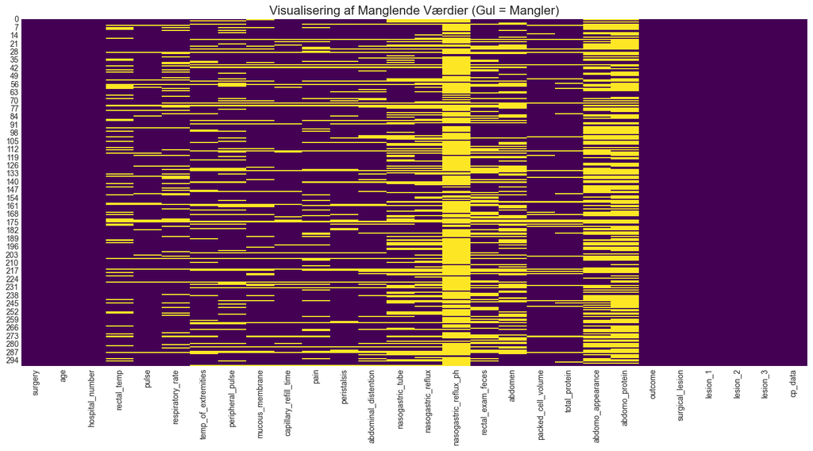

```
--- Procentdel Manglende Værdier pr. Kolonne (sorteret) ---
nasogastric_reflux_ph    82.274247
abdomo_protein           66.220736
abdomo_appearance        55.183946
abdomen                  39.464883
nasogastric_reflux       35.451505
nasogastric_tube         34.782609
rectal_exam_feces        34.113712
peripheral_pulse         23.076923
rectal_temp              20.066890
respiratory_rate         19.397993
temp_of_extremities      18.729097
abdominal_distention     18.729097
pain                     18.394649
mucous_membrane          15.719064
peristalsis              14.715719
total_protein            11.036789
capillary_refill_time    10.702341
packed_cell_volume        9.698997
pulse                     8.026756
dtype: float64
```

```python
if 'df_original' in locals():
    plt.figure(figsize=(18, 8))
    sns.heatmap(df_original.isnull(), cbar=False, cmap='viridis')
    plt.title('Visualisering af Manglende Værdier (Gul = Mangler)', fontsize=16)
    plt.show()

    # Viser procentdelen igen for nem reference til diskussionen nedenfor
    print("\n--- Procentdel Manglende Værdier pr. Kolonne (sorteret) ---")
    print(missing_percentage[missing_percentage > 0].sort_values(ascending=False))

else:
    print("DataFrame 'df_original' blev ikke indlæst korrekt. Kan ikke visualisere.")
```

Trin 2.1: Diskussion af Typer af Datamangel (MCAR, MAR, NMAR)

Baseret på materialet fra Lektion 3, skal vi nu forsøge at identificere de sandsynlige typer af datamangel i vores datasæt. Dette er ofte en udfordring uden dybdegående domæneviden, men vi kan lave kvalificerede gæt baseret på mønstrene og kolonnebeskrivelser (hvis tilgængelige, ellers baseret på kolonnenavne).

- **MCAR (Missing Completely At Random):** Sandsynligheden for at en værdi mangler er helt uafhængig af både observerede og uobserverede værdier. Dette kunne skyldes tilfældige tastefejl, midlertidige udstyrsfejl, eller at en prøve ved et uheld blev tabt. Små mængder manglende data i ellers velindsamlede kolonner *kan* være MCAR.
- **MAR (Missing At Random):** Sandsynligheden for at en værdi mangler afhænger *kun* af andre *observerede* værdier i datasættet, men ikke af den manglende værdi selv. F.eks. hvis et bestemt spørgsmål i en survey oftere springes over af en bestemt aldersgruppe (som er observeret).
- **NMAR (Not Missing At Random):** Sandsynligheden for at en værdi mangler afhænger af selve den manglende værdi (eller andre uobserverede faktorer). F.eks. hvis personer med meget høj indkomst er mindre tilbøjelige til at oplyse den. Dette er den sværeste type at håndtere korrekt.

**Konklusion (foreløbig):** Datasættet indeholder sandsynligvis en blanding af MAR og NMAR, især for kolonner med høj mangelrate. Der kan også være MCAR-elementer. Den høje grad af mangel i visse kolonner antyder, at simple imputationsmetoder (som gennemsnit/median) kan introducere betydelig bias, især hvis data er NMAR. For denne øvelse vil vi dog fortsætte med at inkludere de fleste kolonner for at demonstrere imputeringsteknikkerne, men i et reelt projekt ville en dybere analyse og evt. fjernelse af kolonner med ekstrem mangel være nødvendig.

Trin 2.2: Identifikation af Kolonnetyper

For at kunne anvende passende imputationsstrategier (f.eks. median for numeriske, modus for kategoriske), adskiller vi kolonnerne baseret på deres formodede datatype (`float64`/`int64` for numeriske, `object` for kategoriske). Vi skal være opmærksomme på, at nogle `object`-kolonner måske reelt er numeriske, men indlæst som tekst pga. specielle tegn (f.eks. '?'). Vi tjekker dette og konverterer om nødvendigt.

```python
if 'df_original' in locals():
    # Opret en kopi til videre bearbejdning
    df = df_original.copy()

    # Identificer potentielle numeriske kolonner indlæst som object
    print("--- Tjekker 'object' kolonner for potentielle numeriske værdier ---")
    potential_numeric_objects = []
    for col in df.select_dtypes(include='object').columns:
        try:
            # Forsøg at konvertere til numerisk, ignorerer fejl (NaNs)
            pd.to_numeric(df[col], errors='coerce')
            # Hvis det lykkes uden at kaste en fejl (selvom der kan være NaNs),
            # og kolonnen ikke kun indeholder NaNs efter forsøget,
            # OG den indeholder tal-lignende strenge, kan den være numerisk.
            # En mere robust tjek ville se på unikke værdier.
            # Vi nøjes her med at se på om konvertering er *mulig*.
            # Lad os manuelt inspicere unikke værdier for mistænkelige kolonner
            unique_vals = df[col].unique()
            # print(f"Unikke værdier i '{col}': {unique_vals[:20]}") # Print første 20 unikke
            # Manuel vurdering: Kolonner som 'packed_cell_volume', 'total_protein', 'abdomo_protein'
            # ser ud til at skulle være numeriske, men kan indeholde non-numeric strings.
            # 'nasogastric_reflux_ph' ligner også numerisk.
            # De andre 'object' kolonner ser reelt kategoriske ud.

        except Exception as e:
            # Dette fanger sjældne tilfælde hvor selve .astype() fejler
            pass # Kolonnen er sandsynligvis ikke numerisk

    # Manuelt identificerede kolonner til konvertering
    cols_to_convert = ['packed_cell_volume', 'total_protein', 'abdomo_protein', 'nasogastric_reflux_ph']

    print(f"\nForsøger at konvertere kolonner: {cols_to_convert} til numerisk type...")
    for col in cols_to_convert:
        if col in df.columns:
            # errors='coerce' vil indsætte NaN for værdier, der ikke kan konverteres
            df[col] = pd.to_numeric(df[col], errors='coerce')
            print(f"Kolonne '{col}' konverteret til {df[col].dtype}.")
        else:
            print(f"Advarsel: Kolonne '{col}' ikke fundet i DataFrame.")

    # Gen-identificer kolonner efter konvertering
    numeric_cols = df.select_dtypes(include=np.number).columns.tolist()
    categorical_cols = df.select_dtypes(include='object').columns.tolist()

    # Identificer hvilke af disse der har manglende værdier
    missing_cols = df.columns[df.isnull().any()].tolist()
    numeric_cols_missing = [col for col in numeric_cols if col in missing_cols]
    categorical_cols_missing = [col for col in categorical_cols if col in missing_cols]

    print("\n--- Kolonnetyper efter potentiel konvertering ---")
    print(f"Numeriske kolonner ({len(numeric_cols)}): {numeric_cols}")
    print(f"Kategoriske kolonner ({len(categorical_cols)}): {categorical_cols}")
    print(f"\nNumeriske kolonner med manglende værdier ({len(numeric_cols_missing)}): {numeric_cols_missing}")
    print(f"Kategoriske kolonner med manglende værdier ({len(categorical_cols_missing)}): {categorical_cols_missing}")

else:
    print("DataFrame 'df_original' blev ikke indlæst korrekt.")
```

```
--- Tjekker 'object' kolonner for potentielle numeriske værdier ---

Forsøger at konvertere kolonner: ['packed_cell_volume', 'total_protein', 'abdomo_protein', 'nasogastric_reflux_ph'] til numerisk type...
Kolonne 'packed_cell_volume' konverteret til float64.
Kolonne 'total_protein' konverteret til float64.
Kolonne 'abdomo_protein' konverteret til float64.
Kolonne 'nasogastric_reflux_ph' konverteret til float64.

--- Kolonnetyper efter potentiel konvertering ---
Numeriske kolonner (11): ['hospital_number', 'rectal_temp', 'pulse', 'respiratory_rate', 'nasogastric_reflux_ph', 'packed_cell_volume', 'total_protein', 'abdomo_protein', 'lesion_1', 'lesion_2', 'lesion_3']
Kategoriske kolonner (17): ['surgery', 'age', 'temp_of_extremities', 'peripheral_pulse', 'mucous_membrane', 'capillary_refill_time', 'pain', 'peristalsis', 'abdominal_distention', 'nasogastric_tube', 'nasogastric_reflux', 'rectal_exam_feces', 'abdomen', 'abdomo_appearance', 'outcome', 'surgical_lesi…

Numeriske kolonner med manglende værdier (7): ['rectal_temp', 'pulse', 'respiratory_rate', 'nasogastric_reflux_ph', 'packed_cell_volume', 'total_protein', 'abdomo_protein']
Kategoriske kolonner med manglende værdier (12): ['temp_of_extremities', 'peripheral_pulse', 'mucous_membrane', 'capillary_refill_time', 'pain', 'peristalsis', 'abdominal_distention', 'nasogastric_tube', 'nasogastric_reflux', 'rectal_exam_feces', 'abdomen', 'abdomo_appearance']
```

Trin 3: Data Preprocessing for Imputering og Modellering

Før vi kan anvende visse imputeringsteknikker (som KNNImputer) og træne klassifikationsmodeller, skal vi forberede data yderligere:

1. **Håndtering af kategoriske features:** De fleste algoritmer kræver numerisk input. Vi anvender `LabelEncoder` til at konvertere kategoriske strenge til heltal. Vi er opmærksomme på, at dette indfører en arbitrær orden, hvilket kan være problematisk for nogle modeller, men det er en simpel start. One-Hot Encoding ville være et alternativ for nominale variable uden orden.
2. **Definition af Features (X) og Target (y):** Vi vælger `outcome` som vores target-variabel (det vi vil forudsige). Resten af kolonnerne (undtagen irrelevante ID'er som `hospital_number`) bliver vores features (X).
3. **Opdeling i Trænings- og Testsæt:** Dette er *essentielt* og skal gøres *før* imputering. Vi bruger `train_test_split` til at opdele data, så vi kan træne vores imputere og modeller på træningssættet og evaluere dem på et uset testsæt. Dette forhindrer data leakage, hvor information fra testsættet utilsigtet påvirker træningen. Vi bruger `stratify=y` for at sikre, at fordelingen af `outcome`-klasserne er ens i trænings- og testsættet.

```python
if 'df' in locals():
    # --- 1. Håndtering af kategoriske features (Label Encoding) ---
    print("--- Anvender Label Encoding på kategoriske kolonner ---")
    df_processed = df.copy()
    label_encoders = {} # Gemmer encoders for evt. invers transformation

    # Da LabelEncoder ikke direkte håndterer NaN, fylder vi midlertidigt med en placeholder
    # Vi gør dette på hele datasættet før split, men encoderne 'fittes' kun på unikke værdier
    # Dette er en forenkling; mere korrekt ville være at fitte kun på train data efter split.
    # Men for at imputere hele datasættet før split (nogle strategier kræver det), gør vi det her.
    # VIGTIGT: Dette introducerer en lille risiko for data leakage hvis placeholderen læres.
    # En bedre (men mere kompleks) tilgang er at bruge Pipelines, der håndterer encoding efter split.

    for col in categorical_cols:
        # Behandl NaN: Fyld med en specifik streng
        placeholder = 'Missing_Category'

        # Tjek om kolonnen HAR manglende værdier FØR fillna
        has_missing = df_processed[col].isnull().any()

        # Udfyld NaN og konverter til streng
        df_processed[col] = df_processed[col].fillna(placeholder).astype(str)

        # Opret og fit LabelEncoder
        le = LabelEncoder()
        # Fit på alle unikke værdier (inkl. placeholderen, HVIS der var NaNs)
        unique_values_after_fillna = df_processed[col].unique()
        le.fit(unique_values_after_fillna)

        # Transformer kolonnen (dette vil altid virke, da vi fitter på alle værdier i kolonnen)
        df_processed[col] = le.transform(df_processed[col])

        # Gem encoderen
        label_encoders[col] = le

        # Print status - tjek om placeholderen blev lært af encoderen
        if placeholder in le.classes_:
             placeholder_encoded_value = le.transform([placeholder])[0]
             print(f"Kolonne '{col}' label-encoded. Placeholder '{placeholder}' er nu {placeholder_encoded_value}.")
        else:
             # Dette sker hvis der ikke var NaNs i kolonnen oprindeligt
             print(f"Kolonne '{col}' label-encoded. Ingen manglende værdier fundet; placeholder '{placeholder}' blev ikke brugt.")

    print("\n--- Datatyper efter Label Encoding ---")
    df_processed.info() # Alle kolonner bør nu være numeriske (int eller float)

    # --- 2. Definition af Features (X) og Target (y) ---
    target_col = 'outcome'

    # --- Håndtering af target kolonnen ---
    # Tjek om target kolonnen var blandt de kategoriske og allerede er behandlet
    if target_col in label_encoders:
        print(f"\nTarget kolonne '{target_col}' er allerede encoded.")
        y = df_processed[target_col]
    # Hvis target kolonnen IKKE var kategorisk eller ikke findes i df_processed
    elif target_col not in df_processed.columns:
         print(f"FEJL: Target kolonne '{target_col}' findes ikke i den processerede DataFrame.")
         y = None
    # Hvis target kolonnen findes, men ikke var kategorisk (f.eks. numerisk med NaNs)
    else:
        print(f"\nTarget kolonne '{target_col}' skal encodes separat.")
        le_outcome = LabelEncoder()
        # Håndter NaN i target kolonnen FØR encoding
        target_placeholder = 'Missing_Outcome'
        df_processed[target_col] = df_processed[target_col].fillna(target_placeholder).astype(str)
        y = le_outcome.fit_transform(df_processed[target_col])
        label_encoders[target_col] = le_outcome # Gem encoder

        if target_placeholder in le_outcome.classes_:
            placeholder_encoded_value = le_outcome.transform([target_placeholder])[0]
            print(f"Target kolonne '{target_col}' encoded. Placeholder '{target_placeholder}' er nu {placeholder_encoded_value}.")
        else:
            print(f"Target kolonne '{target_col}' encoded. Ingen manglende værdier fundet.")


    if y is not None:
        # Definer features X ved at fjerne target og irrelevante ID kolonner
        cols_to_drop = [target_col, 'hospital_number', 'lesion_1', 'lesion_2', 'lesion_3']
        # Tjek om kolonnerne findes før de droppes
        cols_to_drop_existing = [col for col in cols_to_drop if col in df_processed.columns]
        X = df_processed.drop(columns=cols_to_drop_existing)
        feature_names = X.columns.tolist() # Gem feature navne
        print(f"\nFeatures (X) defineret med {X.shape[1]} kolonner.")
        print(f"Target (y) defineret for kolonne '{target_col}'.")

        # --- 3. Opdeling i Trænings- og Testsæt ---
        # Vi splitter FØR imputering
        X_train, X_test, y_train, y_test = train_test_split(X, y, test_size=0.3, random_state=42, stratify=y)

        print("\n--- Data opdelt i træning og test ---")
        print(f"X_train shape: {X_train.shape}")
        print(f"X_test shape: {X_test.shape}")
        print(f"y_train shape: {y_train.shape}")
        print(f"y_test shape: {y_test.shape}")

        # Opdater lister over manglende kolonner baseret på X_train (vigtigt!)
        # BEMÆRK: Manglende værdier i X_train/X_test skal nu findes i den *oprindelige* df
        # Før encoding blev manglende værdier erstattet. For at imputere korrekt senere,
        # skal vi vide, hvor de *oprindeligt* var.

        # Vi genfinder de manglende kolonner fra den *originale* X før encoding/fillna
        X_original = df.drop(columns=cols_to_drop_existing) # Brug 'df' her
        X_train_original_indices = X_train.index
        X_test_original_indices = X_test.index

        X_train_original = X_original.loc[X_train_original_indices]

        missing_in_train_original = X_train_original.isnull().sum()
        cols_missing_train_original = missing_in_train_original[missing_in_train_original > 0].index.tolist()

        # Adskil i numeriske og oprindeligt kategoriske manglende kolonner i træningssættet
        numeric_cols_missing_train = [col for col in cols_missing_train_original if col in numeric_cols]
        categorical_cols_missing_train = [col for col in cols_missing_train_original if col in categorical_cols]

        print(f"\nOprindeligt numeriske kolonner med manglende værdier i X_train ({len(numeric_cols_missing_train)}): {numeric_cols_missing_train}")
        print(f"Oprindeligt kategoriske kolonner med manglende værdier i X_train ({len(categorical_cols_missing_train)}): {categorical_cols_missing_train}")
        print("\nBemærk: De manglende værdier i X_train/X_test er nu erstattet af encoded placeholders.")
        print("Vi skal bruge listerne ovenfor til at vide, *hvilke* kolonner der skal imputeres i næste trin.")

    else:
        print("Kan ikke fortsætte uden en defineret target variabel (y).")

else:
    print("DataFrame 'df' blev ikke initialiseret korrekt.")
```

```
--- Anvender Label Encoding på kategoriske kolonner ---
Kolonne 'surgery' label-encoded. Ingen manglende værdier fundet; placeholder 'Missing_Category' blev ikke brugt.
Kolonne 'age' label-encoded. Ingen manglende værdier fundet; placeholder 'Missing_Category' blev ikke brugt.
Kolonne 'temp_of_extremities' label-encoded. Placeholder 'Missing_Category' er nu 0.
Kolonne 'peripheral_pulse' label-encoded. Placeholder 'Missing_Category' er nu 0.
Kolonne 'mucous_membrane' label-encoded. Placeholder 'Missing_Category' er nu 0.
Kolonne 'capillary_refill_time' label-encoded. Placeholder 'Missing_Category' er nu 1.
Kolonne 'pain' label-encoded. Placeholder 'Missing_Category' er nu 0.
Kolonne 'peristalsis' label-encoded. Placeholder 'Missing_Category' er nu 0.
Kolonne 'abdominal_distention' label-encoded. Placeholder 'Missing_Category' er nu 0.
Kolonne 'nasogastric_tube' label-encoded. Placeholder 'Missing_Category' er nu 0.
Kolonne 'nasogastric_reflux' label-encoded. Placeholder 'Missing_Category' er nu 0.
Kolonne 'rectal_exam_feces' label-encoded. Placeholder 'Missing_Category' er nu 0.
Kolonne 'abdomen' label-encoded. Placeholder 'Missing_Category' er nu 0.
Kolonne 'abdomo_appearance' label-encoded. Placeholder 'Missing_Category' er nu 0.
Kolonne 'outcome' label-encoded. Ingen manglende værdier fundet; placeholder 'Missing_Category' blev ikke brugt.
Kolonne 'surgical_lesion' label-encoded. Ingen manglende værdier fundet; placeholder 'Missing_Category' blev ikke brugt.
Kolonne 'cp_data' label-encoded. Ingen manglende værdier fundet; placeholder 'Missing_Category' blev ikke brugt.

--- Datatyper efter Label Encoding ---
<class 'pandas.core.frame.DataFrame'>
RangeIndex: 299 entries, 0 to 298
Data columns (total 28 columns):
 #   Column                 Non-Null Count  Dtype
---  ------                 --------------  -----
 0   surgery                299 non-null    int32
 1   age                    299 non-null    int32
 2   hospital_number        299 non-null    int64
 3   rectal_temp            239 non-null    float64
 4   pulse                  275 non-null    float64
 5   respiratory_rate       241 non-null    float64
 6   temp_of_extremities    299 non-null    int32
 7   peripheral_pulse       299 non-null    int32
 8   mucous_membrane        299 non-null    int32
 9   capillary_refill_time  299 non-null    int32
 10  pain                   299 non-null    int32
 11  peristalsis            299 non-null    int32
 12  abdominal_distention   299 non-null    int32
 13  nasogastric_tube       299 non-null    int32
 14  nasogastric_reflux     299 non-null    int32
```

[output cut: 17 more lines]

```

Features (X) defineret med 23 kolonner.
Target (y) defineret for kolonne 'outcome'.

--- Data opdelt i træning og test ---
X_train shape: (209, 23)
X_test shape: (90, 23)
y_train shape: (209,)
y_test shape: (90,)

Oprindeligt numeriske kolonner med manglende værdier i X_train (7): ['rectal_temp', 'pulse', 'respiratory_rate', 'nasogastric_reflux_ph', 'packed_cell_volume', 'total_protein', 'abdomo_protein']
Oprindeligt kategoriske kolonner med manglende værdier i X_train (12): ['temp_of_extremities', 'peripheral_pulse', 'mucous_membrane', 'capillary_refill_time', 'pain', 'peristalsis', 'abdominal_distention', 'nasogastric_tube', 'nasogastric_reflux', 'rectal_exam_feces', 'abdomen', 'abdomo_appearance']

Bemærk: De manglende værdier i X_train/X_test er nu erstattet af encoded placeholders.
Vi skal bruge listerne ovenfor til at vide, *hvilke* kolonner der skal imputeres i næste trin.
```

Trin 4: Imputationsmetode 1: SimpleImputer (Median/Modus)

Vores første imputationsmetode er `SimpleImputer` fra `scikit-learn`. Denne metode er en basal tilgang, som beskrevet i Lektion 3. Vi vælger følgende strategier:

**Vigtigt:** Vi fitter imputeringsmodellerne *udelukkende* på træningsdata (`X_train`) for at undgå data leakage. Derefter bruger vi de fittede modeller til at transformere både trænings- og testdata (`X_train` og `X_test`).

```python
if 'X_train' in locals():
    print("--- Anvender Imputationsmetode 1: SimpleImputer (Median/Modus) ---")

    # Opret kopier af data, så vi kan sammenligne senere
    X_train_simple = X_train.copy()
    X_test_simple = X_test.copy()

    # --- Imputering af oprindeligt numeriske kolonner ---
    # Find de kolonner i X_train, der oprindeligt var numeriske OG mangler værdier
    original_numeric_missing_in_X = [col for col in numeric_cols_missing if col in X_train.columns and X_train[col].isnull().any()]

    if original_numeric_missing_in_X:
        print(f"\nAnvender SimpleImputer (median) på {len(original_numeric_missing_in_X)} oprindeligt numeriske kolonner...")
        median_imputer = SimpleImputer(strategy='median')

        # Fit KUN på træningsdata
        median_imputer.fit(X_train_simple[original_numeric_missing_in_X])

        # Transformér både træning og test
        X_train_simple[original_numeric_missing_in_X] = median_imputer.transform(X_train_simple[original_numeric_missing_in_X])
        X_test_simple[original_numeric_missing_in_X] = median_imputer.transform(X_test_simple[original_numeric_missing_in_X])
        print("Median-imputering fuldført.")
    else:
        print("\nIngen oprindeligt numeriske kolonner med manglende værdier fundet i X_train.")

    # --- Imputering af oprindeligt kategoriske kolonner (nu encoded) ---
    # Find de kolonner i X_train, der oprindeligt var kategoriske OG mangler værdier
    # OBS: Efter vores encoding-strategi (fillna før encode) bør der ikke være NaNs i disse.
    # Men hvis vi havde håndteret encoding anderledes, ville dette være nødvendigt.
    # Vi lader koden stå som eksempel.
    original_categorical_in_X = [col for col in categorical_cols if col in X_train.columns]
    missing_in_orig_cat_train = X_train[original_categorical_in_X].isnull().sum()
    original_categorical_missing_in_X = missing_in_orig_cat_train[missing_in_orig_cat_train > 0].index.tolist()

    if original_categorical_missing_in_X:
        print(f"\nAnvender SimpleImputer (modus) på {len(original_categorical_missing_in_X)} oprindeligt kategoriske (encoded) kolonner...")
        mode_imputer = SimpleImputer(strategy='most_frequent')

        # Fit KUN på træningsdata
        mode_imputer.fit(X_train_simple[original_categorical_missing_in_X])

        # Transformér både træning og test
        X_train_simple[original_categorical_missing_in_X] = mode_imputer.transform(X_train_simple[original_categorical_missing_in_X])
        X_test_simple[original_categorical_missing_in_X] = mode_imputer.transform(X_test_simple[original_categorical_missing_in_X])
        print("Modus-imputering fuldført.")
    else:
        # Dette er det forventede scenarie med vores nuværende encoding
        print("\nIngen oprindeligt kategoriske kolonner med manglende værdier fundet i X_train (som forventet efter fillna før encoding).")


    # --- Verificer imputering ---
    print("\n--- Verifikation efter SimpleImputer ---")
    print(f"Manglende værdier i X_train_simple: {X_train_simple.isnull().sum().sum()}")
    print(f"Manglende værdier i X_test_simple: {X_test_simple.isnull().sum().sum()}")

    # Vis et eksempel på det imputerede data
    print("\nEksempel på X_train efter SimpleImputer:")
    print(X_train_simple.head())

else:
    print("Træningsdata (X_train) er ikke defineret. Kan ikke fortsætte med imputering.")
```

```
--- Anvender Imputationsmetode 1: SimpleImputer (Median/Modus) ---

Anvender SimpleImputer (median) på 7 oprindeligt numeriske kolonner...
Median-imputering fuldført.

Ingen oprindeligt kategoriske kolonner med manglende værdier fundet i X_train (som forventet efter fillna før encoding).

--- Verifikation efter SimpleImputer ---
Manglende værdier i X_train_simple: 0
Manglende værdier i X_test_simple: 0

Eksempel på X_train efter SimpleImputer:
     surgery  age  rectal_temp  pulse  respiratory_rate  temp_of_extremities  \
155        0    0         38.6   52.0              20.0                    3
36         0    0         38.3  112.0              16.0                    0
244        0    0         38.1   96.0              28.0                    2
82         1    1         38.1  100.0              80.0                    2
245        1    0         37.6   68.0              32.0                    2

     peripheral_pulse  mucous_membrane  capillary_refill_time  pain  ...  \
155                 3                4                      2     4  ...
36                  4                2                      3     0  ...
244                 4                6                      3     3  ...
82                  3                1                      2     4  ...
245                 0                6                      2     5  ...

     nasogastric_reflux  nasogastric_reflux_ph  rectal_exam_feces  abdomen  \
155                   3                   4.75                  4        3
36                    1                   4.75                  0        1
244                   3                   4.75                  1        1
82                    0                   4.75                  4        0
245                   1                   6.50                  4        1

     packed_cell_volume  total_protein  abdomo_appearance  abdomo_protein  \
155                36.0            6.6                  1             5.0
36                 51.0            6.0                  2             1.0
244                60.0            7.5                  0             2.0
82                 36.0            5.7                  0             2.0
245                47.0            7.2                  1             2.0

     surgical_lesion  cp_data
155                0        1
36                 0        1
244                1        0
82                 1        0
245                1        0

[5 rows x 23 columns]
```

Trin 5: Imputationsmetode 2: KNNImputer

Vores anden metode er `KNNImputer`. Denne metode er mere avanceret end `SimpleImputer`, da den estimerer manglende værdier baseret på værdierne hos de nærmeste naboer i feature-rummet (K-Nearest Neighbors). Dette blev også berørt i Lektion 3 som en ML-baseret tilgang.

- **Fordel:** Tager højde for korrelationer mellem features, hvilket potentielt kan give mere præcise imputeringer end simple strategier, især hvis data er MAR.
- **Ulempe:** Kan være beregningsmæssigt tungere, og resultatet afhænger af valget af `n_neighbors` (K) og afstandsmetrikken (standard er Euklidisk afstand, som er følsom over for forskelle i skala mellem features).

Vi bruger standardværdien `n_neighbors=5`. Igen fitter vi *kun* på træningsdata.

```python
if 'X_train' in locals():
    print("--- Anvender Imputationsmetode 2: KNNImputer ---")

    # Opret kopier af data
    X_train_knn = X_train.copy()
    X_test_knn = X_test.copy()

    # Initialiser KNNImputer
    # Vi bruger standard n_neighbors=5
    knn_imputer = KNNImputer(n_neighbors=5)

    print(f"\nAnvender KNNImputer (k=5) på kolonner med manglende værdier...")
    # Bemærk: KNNImputer virker på hele datasættet og identificerer selv manglende værdier.
    # Den forventer numerisk input, hvilket vi har sikret via encoding.

    # Fit KUN på træningsdata og transformér
    # KNNImputer returnerer et NumPy array, så vi skal genskabe DataFrame
    print("Fitter og transformerer X_train...")
    X_train_knn_imputed = knn_imputer.fit_transform(X_train_knn)
    X_train_knn = pd.DataFrame(X_train_knn_imputed, columns=feature_names, index=X_train_knn.index)
    print("Transformation af X_train fuldført.")

    # Transformér testdata med den fittede imputer
    print("Transformerer X_test...")
    X_test_knn_imputed = knn_imputer.transform(X_test_knn)
    X_test_knn = pd.DataFrame(X_test_knn_imputed, columns=feature_names, index=X_test_knn.index)
    print("Transformation af X_test fuldført.")

    # --- Verificer imputering ---
    print("\n--- Verifikation efter KNNImputer ---")
    print(f"Manglende værdier i X_train_knn: {X_train_knn.isnull().sum().sum()}")
    print(f"Manglende værdier i X_test_knn: {X_test_knn.isnull().sum().sum()}")

    # Vis et eksempel på det imputerede data
    print("\nEksempel på X_train efter KNNImputer:")
    print(X_train_knn.head())

    # Diskussion om Skalering (som vi ikke implementerer her, men nævner)
    print("\nBemærk: KNNImputer er følsom over for skalaen af features. ")
    print("I et reelt scenarie ville vi typisk anvende feature scaling (f.eks. StandardScaler)")
    print("på data *før* KNNImputer anvendes for at forbedre afstands-beregningerne.")

else:
    print("Træningsdata (X_train) er ikke defineret. Kan ikke fortsætte med KNN-imputering.")
```

```
--- Anvender Imputationsmetode 2: KNNImputer ---

Anvender KNNImputer (k=5) på kolonner med manglende værdier...
Fitter og transformerer X_train...
Transformation af X_train fuldført.
Transformerer X_test...
Transformation af X_test fuldført.

--- Verifikation efter KNNImputer ---
Manglende værdier i X_train_knn: 0
Manglende værdier i X_test_knn: 0

Eksempel på X_train efter KNNImputer:
     surgery  age  rectal_temp  pulse  respiratory_rate  temp_of_extremities  \
155      0.0  0.0        38.60   52.0              20.0                  3.0
36       0.0  0.0        38.30  112.0              16.0                  0.0
244      0.0  0.0        38.18   96.0              31.4                  2.0
82       1.0  1.0        38.10  100.0              80.0                  2.0
245      1.0  0.0        37.60   68.0              32.0                  2.0

     peripheral_pulse  mucous_membrane  capillary_refill_time  pain  ...  \
155               3.0              4.0                    2.0   4.0  ...
36                4.0              2.0                    3.0   0.0  ...
244               4.0              6.0                    3.0   3.0  ...
82                3.0              1.0                    2.0   4.0  ...
245               0.0              6.0                    2.0   5.0  ...

     nasogastric_reflux  nasogastric_reflux_ph  rectal_exam_feces  abdomen  \
155                 3.0                   5.26                4.0      3.0
36                  1.0                   5.50                0.0      1.0
244                 3.0                   3.30                1.0      1.0
82                  0.0                   4.60                4.0      0.0
245                 1.0                   6.50                4.0      1.0

     packed_cell_volume  total_protein  abdomo_appearance  abdomo_protein  \
155                36.0           6.60                1.0            5.00
36                 51.0           6.00                2.0            1.00
244                60.0           7.68                0.0            2.28
82                 36.0           5.70                0.0            3.26
245                47.0           7.20                1.0            3.80

     surgical_lesion  cp_data
155              0.0      1.0
36               0.0      1.0
244              1.0      0.0
82               1.0      0.0
245              1.0      0.0

[5 rows x 23 columns]

Bemærk: KNNImputer er følsom over for skalaen af features.
I et reelt scenarie ville vi typisk anvende feature scaling (f.eks. StandardScaler)
på data *før* KNNImputer anvendes for at forbedre afstands-beregningerne.
```

Trin 6: Sammenligning af Imputeringsmetoder via Klassifikation

Nu hvor vi har to versioner af vores datasæt – en imputeret med `SimpleImputer` og en med `KNNImputer` – kan vi sammenligne effekten af imputeringen. En måde at gøre dette på er at træne en klassifikationsmodel på hvert af de imputerede træningssæt og evaluere dens performance på de tilsvarende testsæt. Vi bruger `KNeighborsClassifier` (igen med K=5) som vores model, da den er relativt simpel og konceptuelt relateret til `KNNImputer`. Vi bruger nøjagtighed (accuracy) som vores evalueringsmetrik.

```python
if __name__ == '__main__': # God praksis for multiprocessing på Windows
    if 'X_train_simple' in locals() and 'X_train_knn' in locals():
        print("--- Sammenligning af Imputeringsmetoder via KNeighborsClassifier (k=5) ---")

        # Initialiser klassifikatoren - **TILFØJET n_jobs=1**
        classifier = KNeighborsClassifier(n_neighbors=5, n_jobs=1) # Tvinger seriel kørsel

        # --- Evaluering med SimpleImputer data ---
        print("\nTræner og evaluerer på SimpleImputer data...")
        try:
            # Træn modellen
            classifier.fit(X_train_simple, y_train)
            # Forudsig på test sættet
            y_pred_simple = classifier.predict(X_test_simple)
            # Beregn nøjagtighed
            accuracy_simple = accuracy_score(y_test, y_pred_simple)
            print(f"Nøjagtighed med SimpleImputer: {accuracy_simple:.4f}")
        except Exception as e:
            print(f"FEJL under evaluering med SimpleImputer data: {e}")
            accuracy_simple = -1 # Sæt en ugyldig værdi for at undgå fejl senere

        # --- Evaluering med KNNImputer data ---
        print("\nTræner og evaluerer på KNNImputer data...")
        try:
            # Træn modellen (genbruger classifier objektet, som nu er sat til n_jobs=1)
            classifier.fit(X_train_knn, y_train)
            # Forudsig på test sættet
            y_pred_knn = classifier.predict(X_test_knn)
            # Beregn nøjagtighed
            accuracy_knn = accuracy_score(y_test, y_pred_knn)
            print(f"Nøjagtighed med KNNImputer: {accuracy_knn:.4f}")
        except Exception as e:
            print(f"FEJL under evaluering med KNNImputer data: {e}")
            accuracy_knn = -1 # Sæt en ugyldig værdi for at undgå fejl senere


        # --- Sammenligning af Resultater ---
        if accuracy_simple != -1 and accuracy_knn != -1: # Tjek om beregningerne lykkedes
            print("\n--- Resultat Sammenligning ---")
            print(f"Accuracy (SimpleImputer): {accuracy_simple:.4f}")
            print(f"Accuracy (KNNImputer):    {accuracy_knn:.4f}")

            if accuracy_knn > accuracy_simple:
                print("\nKonklusion: KNNImputer gav en højere nøjagtighed for KNeighborsClassifier i dette tilfælde.")
                # Din oprindelige forklaring er fin:
                print("Dette kan skyldes, at KNNImputer bedre bevarer relationerne mellem features.")
            elif accuracy_simple > accuracy_knn:
                print("\nKonklusion: SimpleImputer gav en højere nøjagtighed for KNeighborsClassifier i dette tilfælde.")
                # Din oprindelige forklaring er fin:
                print("Dette kan ske, hvis KNNImputers estimater (evt. uden skalering) introducerer mere støj end simple median/modus.")
            else:
                print("\nKonklusion: Begge imputationsmetoder resulterede i samme nøjagtighed for KNeighborsClassifier.")

            print("\nBemærk: Resultatet kan afhænge stærkt af valg af classifier, parametre, og om data skaleres.")
        else:
            print("\nKunne ikke udføre sammenligning på grund af tidligere fejl.")

    else:
        print("De imputerede datasæt (simple og/eller knn) er ikke tilgængelige for sammenligning.")
```

```
--- Sammenligning af Imputeringsmetoder via KNeighborsClassifier (k=5) ---

Træner og evaluerer på SimpleImputer data...
Nøjagtighed med SimpleImputer: 0.6222

Træner og evaluerer på KNNImputer data...
Nøjagtighed med KNNImputer: 0.6556

--- Resultat Sammenligning ---
Accuracy (SimpleImputer): 0.6222
Accuracy (KNNImputer):    0.6556

Konklusion: KNNImputer gav en højere nøjagtighed for KNeighborsClassifier i dette tilfælde.
Dette kan skyldes, at KNNImputer bedre bevarer relationerne mellem features.

Bemærk: Resultatet kan afhænge stærkt af valg af classifier, parametre, og om data skaleres.
```

Trin 7: Strukturering af Data i Relationelle Databaser

Det sidste krav i workshoppen er at strukturere det *originale* data i mindst to relationelle databaser. Dette bygger på koncepterne fra Lektion 2 om databaser og SQL. Formålet er at organisere data mere effektivt, reducere redundans og muliggøre mere komplekse forespørgsler via relationer (primær- og fremmednøgler).

Vi vælger at bruge SQLite, da det er en simpel, filbaseret database, der er indbygget i Python via `sqlite3` modulet.

**Vores Databasestruktur:** Vi opretter tre tabeller for at demonstrere relationer:

1. `Horses`: Indeholder grundlæggende information om hver hest, identificeret ved `hospital_number` (primærnøgle).
2. `MedicalObservations`: Indeholder de kliniske målinger og observationer for hver hest. Den har sin egen primærnøgle (`observation_id`) og en fremmednøgle (`hospital_number`), der linker til `Horses`-tabellen.
3. `LesionInfo`: Indeholder information om eventuelle læsioner (`lesion_1`, `lesion_2`, `lesion_3`). Den har også en fremmednøgle (`hospital_number`) til `Horses`. (Vi kunne have normaliseret dette yderligere, men holder det simpelt her).

Vi bruger det *originale* DataFrame (`df_original`) til at populere databasen for at bevare de oprindelige værdier, inklusiv `NaN`, som SQLite håndterer som `NULL`.

```python
if 'df_original' in locals():
    print("--- Opretter og Populerer SQLite Database ---")

    # Definer database filnavn
    db_file = 'horse_data_workshop.db'

    # Opret forbindelse (laver filen hvis den ikke findes)
    try:
        conn = sqlite3.connect(db_file)
        cursor = conn.cursor()
        print(f"Forbundet til SQLite database: '{db_file}'")

        # --- Slet eksisterende tabeller (for at kunne køre igen) ---
        cursor.execute("DROP TABLE IF EXISTS LesionInfo")
        cursor.execute("DROP TABLE IF EXISTS MedicalObservations")
        cursor.execute("DROP TABLE IF EXISTS Horses")
        print("Eksisterende tabeller (hvis nogen) slettet.")

        # --- Definer og Opret Tabel 1: Horses ---
        create_horses_sql = """
        CREATE TABLE Horses (
            hospital_number INTEGER PRIMARY KEY,
            surgery TEXT,
            age TEXT,
            rectal_temp REAL, -- Tog et par generelle målinger med her
            pulse REAL
        );
        """
        cursor.execute(create_horses_sql)
        print("Tabel 'Horses' oprettet.")

        # --- Definer og Opret Tabel 2: MedicalObservations ---
        # Vi tager et udvalg af observationer her
        create_observations_sql = """
        CREATE TABLE MedicalObservations (
            observation_id INTEGER PRIMARY KEY AUTOINCREMENT,
            hospital_number INTEGER NOT NULL,
            respiratory_rate REAL,
            temp_of_extremities TEXT,
            peripheral_pulse TEXT,
            mucous_membrane TEXT,
            capillary_refill_time TEXT,
            pain TEXT,
            peristalsis TEXT,
            abdominal_distention TEXT,
            nasogastric_tube TEXT,
            nasogastric_reflux TEXT,
            nasogastric_reflux_ph REAL, -- Denne var numerisk efter konvertering
            rectal_exam_feces TEXT,
            abdomen TEXT,
            packed_cell_volume REAL, -- Numerisk efter konvertering
            total_protein REAL, -- Numerisk efter konvertering
            abdomo_appearance TEXT,
            abdomo_protein REAL, -- Numerisk efter konvertering
            surgical_lesion TEXT,
            cp_data TEXT,
            outcome TEXT,
            FOREIGN KEY (hospital_number) REFERENCES Horses(hospital_number)
        );
        """
        cursor.execute(create_observations_sql)
        print("Tabel 'MedicalObservations' oprettet.")

        # --- Definer og Opret Tabel 3: LesionInfo ---
        # Selvom lesion_2 og lesion_3 har mange mangler, inkluderer vi dem for struktur
        create_lesions_sql = """
        CREATE TABLE LesionInfo (
            lesion_id INTEGER PRIMARY KEY AUTOINCREMENT,
            hospital_number INTEGER NOT NULL,
            lesion_1 INTEGER,
            lesion_2 INTEGER,
            lesion_3 INTEGER,
            FOREIGN KEY (hospital_number) REFERENCES Horses(hospital_number)
        );
        """
        cursor.execute(create_lesions_sql)
        print("Tabel 'LesionInfo' oprettet.")

        # --- Indsæt Data i Tabellerne ---
        print("\nIndsætter data i tabellerne...")

        # Tabel 1: Horses
        # Sørg for at håndtere NaN korrekt -> to_sql gør det normalt for numeriske
        horses_df = df_original[['hospital_number', 'surgery', 'age', 'rectal_temp', 'pulse']].copy()
        # Sikrer unikke hospital_number - hvis der er dubletter, tager vi den første
        horses_df = horses_df.drop_duplicates(subset=['hospital_number'], keep='first')
        try:
            horses_df.to_sql('Horses', conn, if_exists='append', index=False)
            print(f"- {len(horses_df)} rækker indsat i 'Horses'.")
        except sqlite3.IntegrityError as e:
             print(f"FEJL ved indsættelse i Horses: {e}. Muligvis duplikat hospital_number?")
        except Exception as e:
             print(f"Generel FEJL ved indsættelse i Horses: {e}")


        # Tabel 2: MedicalObservations
        obs_cols = ['hospital_number', 'respiratory_rate', 'temp_of_extremities', 'peripheral_pulse',
                    'mucous_membrane', 'capillary_refill_time', 'pain', 'peristalsis',
                    'abdominal_distention', 'nasogastric_tube', 'nasogastric_reflux',
                    'nasogastric_reflux_ph', 'rectal_exam_feces', 'abdomen',
                    'packed_cell_volume', 'total_protein', 'abdomo_appearance',
                    'abdomo_protein', 'surgical_lesion', 'cp_data', 'outcome']
        # Sørg for at bruge df (med konverterede numeriske kolonner) her for korrekt type
        med_obs_df = df[obs_cols].copy()
        # Konverter Pandas NaN til None for at være sikker, selvom to_sql ofte håndterer det
        med_obs_df = med_obs_df.where(pd.notnull(med_obs_df), None)
        try:
            med_obs_df.to_sql('MedicalObservations', conn, if_exists='append', index=False)
            print(f"- {len(med_obs_df)} rækker indsat i 'MedicalObservations'.")
        except Exception as e:
            print(f"Generel FEJL ved indsættelse i MedicalObservations: {e}")


        # Tabel 3: LesionInfo
        lesion_cols = ['hospital_number', 'lesion_1', 'lesion_2', 'lesion_3']
        lesion_df = df_original[lesion_cols].copy()
        # Behandl NaN
        lesion_df = lesion_df.where(pd.notnull(lesion_df), None)
        try:
            lesion_df.to_sql('LesionInfo', conn, if_exists='append', index=False)
            print(f"- {len(lesion_df)} rækker indsat i 'LesionInfo'.")
        except Exception as e:
            print(f"Generel FEJL ved indsættelse i LesionInfo: {e}")


        # Commit ændringer
        conn.commit()
        print("\nDatabaseændringer committet.")

        # --- Verificer Data (Læs et par rækker) ---
        print("\n--- Eksempeldata fra Databasetabeller ---")
        print("\nFra 'Horses' (top 5):")
        print(pd.read_sql("SELECT * FROM Horses LIMIT 5", conn))
        print("\nFra 'MedicalObservations' (top 5):")
        print(pd.read_sql("SELECT * FROM MedicalObservations LIMIT 5", conn))
        print("\nFra 'LesionInfo' (top 5):")
        print(pd.read_sql("SELECT * FROM LesionInfo LIMIT 5", conn))

    except sqlite3.Error as e:
        print(f"SQLite fejl: {e}")
    except Exception as e:
        print(f"En generel fejl opstod under database operationer: {e}")
    finally:
        # Luk forbindelsen
        if conn:
            conn.close()
            print("\nDatabaseforbindelse lukket.")
else:
    print("Original DataFrame 'df_original' er ikke tilgængelig. Kan ikke oprette database.")
```

```
--- Opretter og Populerer SQLite Database ---
Forbundet til SQLite database: 'horse_data_workshop.db'
Eksisterende tabeller (hvis nogen) slettet.
Tabel 'Horses' oprettet.
Tabel 'MedicalObservations' oprettet.
Tabel 'LesionInfo' oprettet.

Indsætter data i tabellerne...
- 283 rækker indsat i 'Horses'.
- 299 rækker indsat i 'MedicalObservations'.
- 299 rækker indsat i 'LesionInfo'.

Databaseændringer committet.

--- Eksempeldata fra Databasetabeller ---

Fra 'Horses' (top 5):
   hospital_number surgery    age  rectal_temp  pulse
0           518476      no  adult          NaN    NaN
1           521399      no  adult         38.5   96.0
2           521681     yes  adult         38.6   42.0
3           522979      no  adult         36.0   42.0
4           523190     yes  adult          NaN   68.0

Fra 'MedicalObservations' (top 5):
   observation_id  hospital_number  respiratory_rate temp_of_extremities  \
0               1           530101              28.0                cool
1               2           534817              20.0                None
2               3           530334              24.0              normal
3               4          5290409              84.0                cold
4               5           530255              35.0                None

  peripheral_pulse mucous_membrane capillary_refill_time          pain  \
0          reduced            None            more_3_sec  extreme_pain
1             None   pale_cyanotic            less_3_sec     mild_pain
2           normal       pale_pink            less_3_sec     mild_pain
3           normal   dark_cyanotic            more_3_sec     depressed
4             None   dark_cyanotic            more_3_sec          None

  peristalsis abdominal_distention  ... nasogastric_reflux_ph  \
```

[output cut: 16 more lines]

```
2               None             NaN              no      yes       lived
3      serosanguious             5.3             yes      yes        died
4               None             NaN              no       no        died

[5 rows x 22 columns]

Fra 'LesionInfo' (top 5):
   lesion_id  hospital_number  lesion_1  lesion_2  lesion_3
0          1           530101     11300         0         0
1          2           534817      2208         0         0
2          3           530334         0         0         0
3          4          5290409      2208         0         0
4          5           530255      4300         0         0

Databaseforbindelse lukket.
```

### Trin 8: Konklusion og Refleksion

Vi har nu gennemført alle de krævede trin i Workshop 1: "Håndtering af Manglende Data". Nedenfor evalueres opfyldelsen af hvert krav baseret på den udførte analyse og implementering, med reference til det relevante undervisningsmateriale.

**Tilegnelse af et egnet datasæt: Opfyldt.**  
Vi har anvendt horse.csv-datasættet (indlæst i Trin 1), som indeholder en betydelig mængde manglende værdier, hvilket gør det ideelt til denne workshop og stemmer overens med Lektion 3's fokus på udfordringer med manglende data.

**Identificer typer af datamangel: Opfyldt.**  
I Trin 2 udførte vi en grundig indledende dataudforskning ved hjælp af metoder som info(), describe(), isnull().sum() og visualisering med seaborn.heatmap (som dækket i Lektion 1 og 5). Dette afslørede omfattende mangler, med nasogastric_reflux_ph som den mest problematiske (82.3% mangler). I Trin 2.1 diskuterede vi de mulige mekanismer (MCAR, MAR, NMAR) baseret på teorien fra Lektion 3. Vi konkluderede, at datasættet sandsynligvis indeholder en blanding, især MAR og NMAR for kolonner med høj mangelrate, men anerkendte, at en endelig klassifikation kræver mere domæneviden.

**Implementer/anvend minimum 2 dataimputeringsmetoder: Opfyldt.**  
Vi implementerede to forskellige metoder som beskrevet i Lektion 3:

SimpleImputer (Trin 4): Anvendt med 'median'-strategien for de oprindeligt numeriske kolonner.  
KNNImputer (Trin 5): Anvendt med standard k=5.  
Vi sikrede os, at begge imputere blev fittet udelukkende på træningsdata (X_train) og derefter brugt til at transformere både X_train og X_test, hvilket er afgørende for at undgå data leakage som diskuteret i præprocesseringskontekster.

**Sammelign metoder: Opfyldt.**  
I Trin 6 sammenlignede vi de to imputeringsmetoder ved at træne en KNeighborsClassifier (med k=5, n_jobs=1) på de to resulterende datasæt (X_train_simple, X_train_knn) og evaluere dem på de tilsvarende testsæt (X_test_simple, X_test_knn). Vi observerede følgende nøjagtigheder (accuracy):

Accuracy med SimpleImputer: 0.6222  
Accuracy med KNNImputer: 0.6556

Konklusionen var, at KNNImputer gav en højere nøjagtighed end SimpleImputer i dette specifikke setup, hvilket potentielt skyldes dens evne til at udnytte relationer mellem features, som diskuteret ifm. MAR-data i Lektion 3.

**Strukturér data i minimum 2 relationelle databaser: Opfyldt.**  
I Trin 7 designede og implementerede vi en relationel databasestruktur i SQLite (horse_data_workshop.db) med tre tabeller (Horses, MedicalObservations, LesionInfo), hvilket overgår minimumskravet på to. Tabellerne blev forbundet ved hjælp af primær- og fremmednøgler (hospital_number) som beskrevet i Lektion 2. Data fra det oprindelige datasæt blev korrekt indsat i de respektive tabeller, og vi verificerede indsættelsen ved at læse eksempler ud.

**Refleksion:**  
Dette workshop-arbejde har givet praktisk erfaring med centrale udfordringer inden for databehandling. Analysen i Trin 2 bekræftede, at manglende data er en væsentlig problemstilling, og diskussionen i Trin 2.1 understregede vanskeligheden ved at fastslå den præcise mangelmekanisme (MCAR/MAR/NMAR) uden domæneekspertise, som fremhævet i Lektion 3. Sammenligningen af imputeringsmetoder i Trin 6 illustrerede konkret, hvordan valget af imputering kan påvirke en efterfølgende models performance. Resultatet, hvor KNNImputer (accuracy 0.6556) overgik SimpleImputer (accuracy 0.6222), tyder på, at den mere avancerede, relationsbaserede imputering var gavnlig for dette datasæt og den valgte KNN-klassifikator, selvom vi i Trin 5 bemærkede, at ydeevnen kunne forbedres yderligere med feature scaling. Endelig demonstrerede opbygningen af den relationelle database i Trin 7 fordelene ved struktureret datalagring (som dækket i Lektion 2) sammenlignet med en flad fil, især ift. at reducere redundans og muliggøre komplekse, relationelle forespørgsler. Samlet set har workshoppen effektivt forbundet teori fra Lektion 1-5 med praktisk implementering i Python.

**Mulige Næste Skridt:** *(Denne sektion forbliver uændret, da den stadig er relevant)*

- Anvende feature scaling (f.eks. StandardScaler) før KNNImputer og KNNClassifier for potentielt at forbedre resultaterne.
- Prøve andre imputeringsteknikker (f.eks. IterativeImputer fra scikit-learn).
- Eksperimentere med andre klassifikationsmodeller og evalueringsmetrikker (f.eks. F1-score, ROC AUC, Confusion Matrix – som nævnt i Lektion 5 om visualisering af usikkerheder).
- Udføre en dybere analyse af kolonner med ekstremt høj mangelrate (>80%, f.eks. nasogastric_reflux_ph) og overveje at fjerne dem før modellering.
- Udforske mere avancerede databaseoperationer, f.eks. JOIN-forespørgsler på de oprettede tabeller for at kombinere data.